# Clean and Explore Doetinchem Data

Laurens Bogaardt

2024-02-26

# Introduction

The purpose of this document is to clean and explore the data of the Doetinchem Cohort Study. This study has followed a sex- and age stratified random sample from the population registers of the municipality of Doetinchem in the Netherlands for the past 30 years (Verschuren et al. 2008). Its aim is to study lifestyle factors and biological risk factors on aspects of health. The participants underwent a health examination about every 5 years since 1987. A key feature of this panel is that characteristics such as weight and height were measured by research assistants instead of being self-reported. However, the Doetinchem dataset is not completely representative of the Netherlands. For example, it lacks representation of ethnic subgroups and the study was not able to sample new cohorts from younger age categories (Picavet et al. 2017).

Before we begin, we need to load the packages *tidyverse*, *haven*, *ggforce* and *vtable* (Wickham et al. 2019; Wickham and Miller 2021; Pedersen 2022; Huntington-Klein 2021). And we set a seed to ensure that all runs of this document produce the same output.

```r
library(tidyverse)
library(haven)
library(ggforce)
library(vtable)
set.seed(456)
```

# Load Input

Let’s load the Doetinchem dataset. Throughout the document, we will limit the output in each step. This is because the Doetinchem data are not open access. To request access to the data, please visit www.rivm.nl/doetinchem-cohort-studie.

```r
doetinchem.data <- read_sas(
  data_file = "../Input-Data/Doetinchem/doetcoh_lcdm_update.sas7bdat",
  col_select = starts_with(
    c(
      "OPRNR",
      "gesl",
      "onddat",
      "ses",
      "leeft",
      "qindex"
    )
  )
)
vtable(doetinchem.data, out = "return", missing = TRUE)
```

| Name | Class | Values | Missing |
| --- | --- | --- | --- |
| OPRNR | numeric | Num: 500002 to 530062 | 0 |
| gesl | numeric | Num: 1 to 2 | 0 |
| onddatr1 | Date | Time: 1987-02-02 to 1991-12-17 | 0 |
| qindexr1 | numeric | Num: 14.711 to 47.361 | 2 |
| leeftr1 | numeric | Num: 20.123 to 59.811 | 0 |
| ses3r1 | numeric | Num: 1 to 3 | 21 |
| qindexr2 | numeric | Num: 15.854 to 48.406 | 291 |
| leeftr2 | numeric | Num: 26.081 to 65.848 | 279 |
| ses3r2 | numeric | Num: 1 to 3 | 303 |
| onddatr2 | Date | Time: 1993-01-19 to 1997-12-10 | 279 |

[output cut: 14 more lines]

# Clean Data

We will examine each variable in the dataset and clean the data when necessary.

## Participant ID

Let’s rename the column indicating the participant ID from *OPRNR* to *participant.id*.

```r
doetinchem.data <- doetinchem.data %>%
  rename(participant.id = OPRNR)
```

We also verify that *participant.id* is not missing for any row in the dataset.

```r
doetinchem.data %>%
  summarise(missing = sum(is.na(participant.id)))
```

| missing |
| --- |
| 0 |

And let’s check that each row contains a unique *participant.id*.

```r
doetinchem.data %>%
  count(participant.id) %>%
  summarise(duplicate = sum(n > 1))
```

| duplicate |
| --- |
| 0 |

## Sex

Let’s rename the column indicating the sex of the participant from *gesl* to *sex* and recode the variable. A *M* will encode males, whereas females are encoded by a *F*.

```r
doetinchem.data <- doetinchem.data %>%
  rename(sex = gesl) %>%
  mutate(
    sex = recode_factor(
      sex,
      "1" = "M",
      "2" = "F"
    )
  )
```

We also verify that there are only two sexes and immediately check whether there are any missing values.

```r
doetinchem.data %>%
  count(sex)
```

| sex | n |
| --- | --- |
| M | 2997 |
| F | 3394 |

## Pivot Dataset

Now that the two time-invariant variables have been examined, we can pivot the dataset such that we get a new row for each participant and each wave.

```r
doetinchem.data <- doetinchem.data %>%
  pivot_longer(
    cols = !c(participant.id, sex),
    names_pattern = "(.*)r(.)",
    names_to = c(".value", "wave"),
    names_transform = list(wave = as.integer)
  )
vtable(doetinchem.data, out = "return", missing = TRUE)
```

| Name | Class | Values | Missing |
| --- | --- | --- | --- |
| participant.id | numeric | Num: 500002 to 530062 | 0 |
| sex | factor | 'M' 'F' | 0 |
| wave | integer | Num: 1 to 6 | 0 |
| onddat | Date | Time: 1987-02-02 to 2018-05-24 | 8956 |
| qindex | numeric | Num: 14.711 to 55.996 | 9036 |
| leeft | numeric | Num: 20.123 to 85.81 | 8956 |
| ses3 | numeric | Num: 1 to 3 | 16481 |

Whenever a participant has missed a wave, all variables other than *participant.id*, *sex* and *wave* will be missing. Let’s check how often this occurs.

```r
doetinchem.data %>%
  summarise(missing = sum(is.na(onddat) & is.na(ses3) & is.na(leeft) & is.na(qindex)))
```

| missing |
| --- |
| 8956 |

Let’s remove these rows from the dataset.

```r
doetinchem.data <- doetinchem.data %>%
  filter(!(is.na(onddat) & is.na(ses3) & is.na(leeft) & is.na(qindex)))
```

## Date

Let’s rename the column indicating the date of the wave from *onddat* to *date*.

```r
doetinchem.data <- doetinchem.data %>%
  rename(date = onddat)
```

We also verify that no date is missing.

```r
doetinchem.data %>%
  summarise(missing = sum(is.na(date)))
```

| missing |
| --- |
| 0 |

Let’s verify that, for each participant, the dates of the waves they participated in are ordered correctly.

```r
doetinchem.data %>%
  group_by(participant.id) %>%
  arrange(wave) %>%
  summarise(
    unsorted = is.unsorted(date),
    .groups = "drop"
  ) %>%
  count(unsorted)
```

| unsorted | n |
| --- | --- |
| FALSE | 6391 |

## Education

Let’s rename the column indicating the level of education of the participant from *ses3* to *education* and recode the variable. Education was measured as the highest level reached and categorised into three levels. The lowest level, encoded by *L*, applies to people with intermediate secondary education or less, the medium level, encoded by *M*, aggregates higher secondary- and intermediate vocational education and highest level, encoded by *H*, includes higher vocational education and university.

```r
doetinchem.data <- doetinchem.data %>%
  rename(education = ses3) %>%
  mutate(
    education = recode_factor(
      education,
      "1" = "L",
      "2" = "M",
      "3" = "H",
      .ordered = TRUE
    )
  )
```

Let’s now check whether any participant is missing all entries for their level of education.

```r
doetinchem.data %>%
  group_by(participant.id) %>%
  summarise(
    missing = all(is.na(education)),
    .groups = "drop"
  ) %>%
  count(missing)
```

| missing | n |
| --- | --- |
| FALSE | 6388 |
| TRUE | 3 |

We will remove these participants from the dataset.

```r
doetinchem.data <- doetinchem.data %>%
  group_by(participant.id) %>%
  filter(!all(is.na(education))) %>%
  ungroup()
```

Let’s now check whether any participant is missing some entries for their level of education.

```r
doetinchem.data %>%
  count(wave, education) %>%
  pivot_wider(
    names_from = wave,
    values_from = n,
    names_prefix = "wave "
  )
```

| education | wave 1 | wave 2 | wave 3 | wave 4 | wave 5 | wave 6 |
| --- | --- | --- | --- | --- | --- | --- |
| L | 3976 | 3419 | 2494 | 2186 | NA | NA |
| M | 1367 | 1556 | 1350 | 1287 | NA | NA |
| H | 1027 | 1113 | 1055 | 1035 | NA | NA |
| NA | 18 | 21 | 15 | 11 | 4016 | 3437 |

Let’s also check, for each participant, whether their highest reached level of education does not go down over time.

```r
doetinchem.data %>%
  group_by(participant.id) %>%
  arrange(wave) %>%
  summarise(
    unsorted = is.unsorted(education, na.rm = TRUE),
    .groups = "drop"
  ) %>%
  count(unsorted)
```

| unsorted | n |
| --- | --- |
| FALSE | 5894 |
| TRUE | 494 |

Some participants are missing their level of education for some of the waves. There are also participants who show inconsistencies in their highest reached level of education over time. Both these problems can be solved by assigning the last available entry as the one representing their true level of education. Although this imputation is not perfect, it is a simple solution which distorts the data as little as possible.

```r
doetinchem.data <- doetinchem.data %>%
  arrange(participant.id, wave) %>%
  group_by(participant.id) %>%
  mutate(education = last(na.omit(education))) %>%
  ungroup()
```

## Age

Let’s rename the column indicating the participant’s age from *leeft* to *age*.

```r
doetinchem.data <- doetinchem.data %>%
  rename(age = leeft)
```

We also verify that there are no missing values.

```r
doetinchem.data %>%
  summarise(missing = sum(is.na(age)))
```

| missing |
| --- |
| 0 |

Let’s check that there are only adults in the dataset.

```r
doetinchem.data %>%
  summarise(minor = sum(age < 18))
```

| minor |
| --- |
| 0 |

Let’s verify that, for each participant, their age never goes down.

```r
doetinchem.data %>%
  group_by(participant.id) %>%
  arrange(wave) %>%
  summarise(
    unsorted = is.unsorted(age),
    .groups = "drop"
  ) %>%
  count(unsorted)
```

| unsorted | n |
| --- | --- |
| FALSE | 6388 |

The time between each wave the participant participated in should be consistent with the age difference between those waves. Let’s check whether this holds for all participants.

```r
doetinchem.data %>%
  group_by(participant.id) %>%
  summarise(
    difference = diff(range(date - age * 365.25)),
    .groups = "drop"
  ) %>%
  summarise(difference = sum(difference > 1))
```

| difference |
| --- |
| 3 |

We remove all participants for whom this time difference is not consistent.

```r
doetinchem.data <- doetinchem.data %>%
  group_by(participant.id) %>%
  filter(diff(range(date - age * 365.25)) < 1) %>%
  ungroup()
```

## BMI

Let’s rename the column indicating the participant’s BMI from *qindex* to *bmi*.

```r
doetinchem.data <- doetinchem.data %>%
  rename(bmi = qindex)
```

We check whether there are any missing values.

```r
doetinchem.data %>%
  summarise(missing = sum(is.na(bmi)))
```

| missing |
| --- |
| 80 |

We remove the rows for which BMI is missing.

```r
doetinchem.data <- doetinchem.data %>%
  filter(!is.na(bmi))
```

In most of their analyses, Statistics Netherlands removes outlying BMI values whereby it uses $14 kg / m^2$ and $50 kg / m^2$ as the lower and upper limits. Let’s check whether we have such outliers in our data.

```r
doetinchem.data %>%
  summarise(
    below = sum(bmi < 14),
    above = sum(bmi > 50),
    min.bmi = min(bmi),
    max.bmi = max(bmi)
  )
```

| below | above | min.bmi | max.bmi |
| --- | --- | --- | --- |
| 0 | 5 | 14.71125 | 55.99595 |

A key feature of the Doetinchem Cohort Study is that characteristics such as weight and height were measured by research assistants instead of being self-reported. So, even though some BMI values are above the threshold, we believe we can trust these values and that there is no need to remove them from our dataset.

## Order Rows and Columns

As a final cleaning step, let’s reorder the columns and arrange the rows of the dataset.

```r
doetinchem.data <- doetinchem.data %>%
  select(participant.id, sex, education, wave, date, age, bmi) %>%
  arrange(participant.id, wave)
```

# Explore Data

We will examine each variable in the dataset, now that the data have been cleaned. But let’s first look at an overview of the dataset.

```r
vtable(doetinchem.data, out = "return", missing = TRUE)
```

| Name | Class | Values | Missing |
| --- | --- | --- | --- |
| participant.id | numeric | Num: 500002 to 530062 | 0 |
| sex | factor | 'M' 'F' | 0 |
| education | ordered | 'H' 'L' 'M' | 0 |
| wave | integer | Num: 1 to 6 | 0 |
| date | Date | Time: 1987-02-02 to 2018-05-24 | 0 |
| age | numeric | Num: 20.123 to 85.81 | 0 |
| bmi | numeric | Num: 14.711 to 55.996 | 0 |

## Participation

Let’s see how many participants we have per wave.

```r
doetinchem.participants.by.wave <- doetinchem.data %>%
  count(wave)
doetinchem.participants.by.wave
```

| wave | n |
| --- | --- |
| 1 | 6383 |
| 2 | 6094 |
| 3 | 4889 |
| 4 | 4504 |
| 5 | 3994 |
| 6 | 3426 |

We can visualise this in a plot.

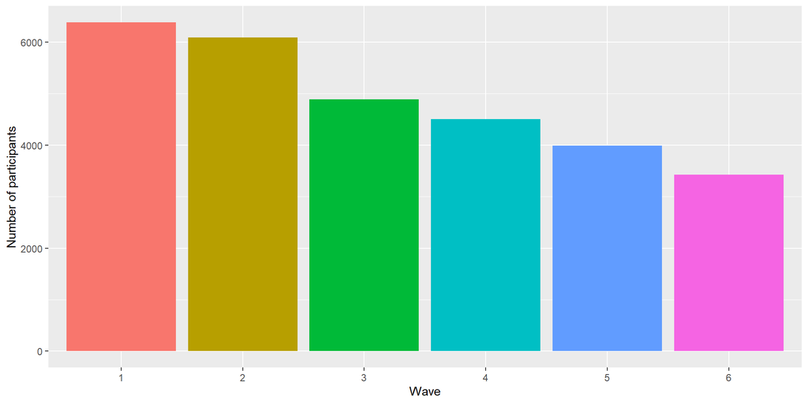

```r
ggplot() +
  geom_col(
    mapping = aes(
      x = factor(wave),
      y = n,
      fill = factor(wave)
    ),
    data = doetinchem.participants.by.wave,
    show.legend = FALSE
  ) +
  labs(
    x = "Wave",
    y = "Number of participants"
  )
```

We can also count how many participants participated in all of the waves and how many in fewer.

```r
doetinchem.number.of.waves <- doetinchem.data %>%
  count(participant.id, name = "waves") %>%
  count(waves)
doetinchem.number.of.waves
```

| waves | n |
| --- | --- |
| 1 | 12 |
| 2 | 1116 |
| 3 | 716 |
| 4 | 701 |
| 5 | 946 |
| 6 | 2894 |

We can visualise this in a plot.

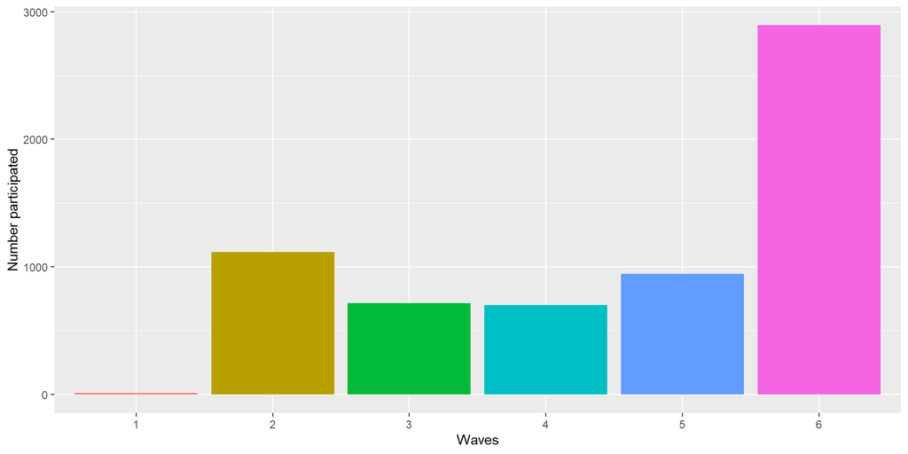

```r
ggplot() +
  geom_col(
    mapping = aes(
      x = factor(waves),
      y = n,
      fill = factor(waves)
    ),
    data = doetinchem.number.of.waves,
    show.legend = FALSE
  ) +
  labs(
    x = "Waves",
    y = "Number participated"
  )
```

For all participants, we can note whether they participated in a wave or not. This can be used to see at what rate participants enter or leave the panel, between each wave.

```r
stratum.per.participant.per.wave <- doetinchem.data %>%
  select(participant.id, wave, date) %>%
  complete(participant.id, wave) %>%
  group_by(participant.id) %>%
  mutate(
    stratum = case_when(
      is.na(date) & cumsum(!is.na(date)) > 0 ~ "Out",
      TRUE ~ "In"
    )
  ) %>%
  ungroup()
```

These data can be visualised, showing the transitions in and out of the panel over time.

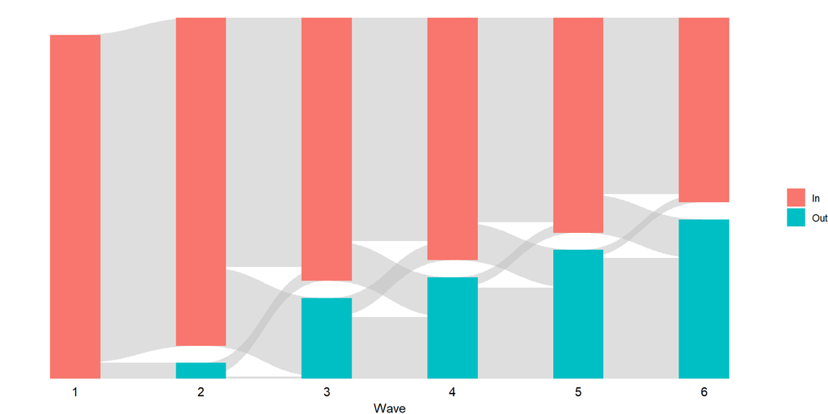

```r
ggplot(
  mapping = aes(
    x = factor(wave),
    id = participant.id,
    split = stratum,
    value = 1,
    fill = stratum
  ),
  data = stratum.per.participant.per.wave
) +
  geom_parallel_sets(
    fill = "grey",
    alpha = 0.5
  ) +
  geom_parallel_sets_axes(axis.width = 0.4) +
  labs(
    x = "Wave",
    fill = ""
  ) +
  theme_void() +
  theme(
    axis.title.x = element_text(margin = margin(t = 4)),
    axis.text.x = element_text(margin = margin(t = -10))
  )
```

## Sex

Let’s check, per wave, what the number and percentages of males and females is.

```r
doetinchem.prevalence.by.wave.and.sex <- doetinchem.data %>%
  count(wave, sex) %>%
  group_by(wave) %>%
  mutate(
    prevalence = n / sum(n)
  ) %>%
  ungroup()
doetinchem.prevalence.by.wave.and.sex
```

| wave | sex | n | prevalence |
| --- | --- | --- | --- |
| 1 | M | 2994 | 0.4690584 |
| 1 | F | 3389 | 0.5309416 |
| 2 | M | 2850 | 0.4676731 |
| 2 | F | 3244 | 0.5323269 |
| 3 | M | 2334 | 0.4773982 |
| 3 | F | 2555 | 0.5226018 |
| 4 | M | 2135 | 0.4740231 |
| 4 | F | 2369 | 0.5259769 |
| 5 | M | 1890 | 0.4732098 |
| 5 | F | 2104 | 0.5267902 |

[output cut: 2 more lines]

We can visualise this in a plot.

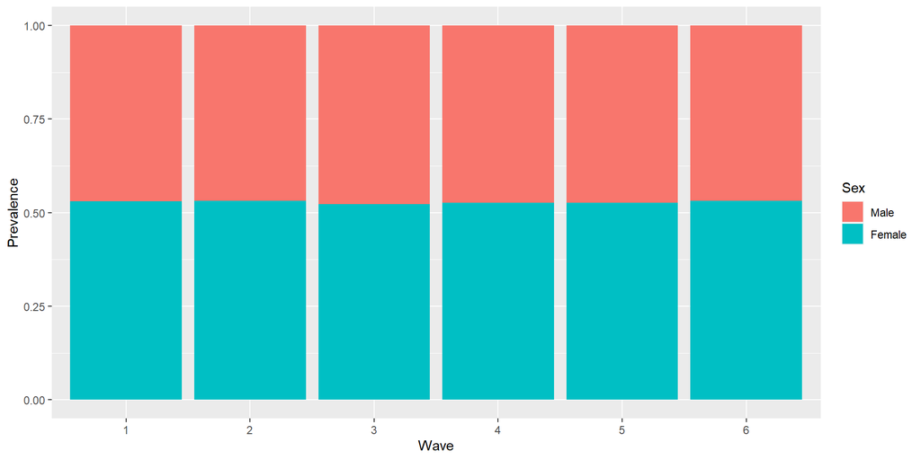

```r
ggplot() +
  geom_col(
    mapping = aes(
      x = factor(wave),
      y = prevalence,
      fill = sex
    ),
    data = doetinchem.prevalence.by.wave.and.sex
  ) +
  labs(
    x = "Wave",
    y = "Prevalence"
  ) +
  scale_fill_discrete(
    name = "Sex",
    label = c("M" = "Male", "F" = "Female")
  )
```

## Education

Let’s check, per wave, what the number and percentages of each of the three levels of education is.

```r
doetinchem.prevalence.by.wave.and.education <- doetinchem.data %>%
  count(wave, education) %>%
  group_by(wave) %>%
  mutate(
    prevalence = n / sum(n)
  ) %>%
  ungroup()
doetinchem.prevalence.by.wave.and.education
```

| wave | education | n | prevalence |
| --- | --- | --- | --- |
| 1 | L | 3434 | 0.5379915 |
| 1 | M | 1686 | 0.2641391 |
| 1 | H | 1263 | 0.1978693 |
| 2 | L | 3270 | 0.5365934 |
| 2 | M | 1604 | 0.2632097 |
| 2 | H | 1220 | 0.2001969 |
| 3 | L | 2443 | 0.4996932 |
| 3 | M | 1368 | 0.2798118 |
| 3 | H | 1078 | 0.2204950 |
| 4 | L | 2182 | 0.4844583 |

[output cut: 8 more lines]

We can visualise this in a plot.

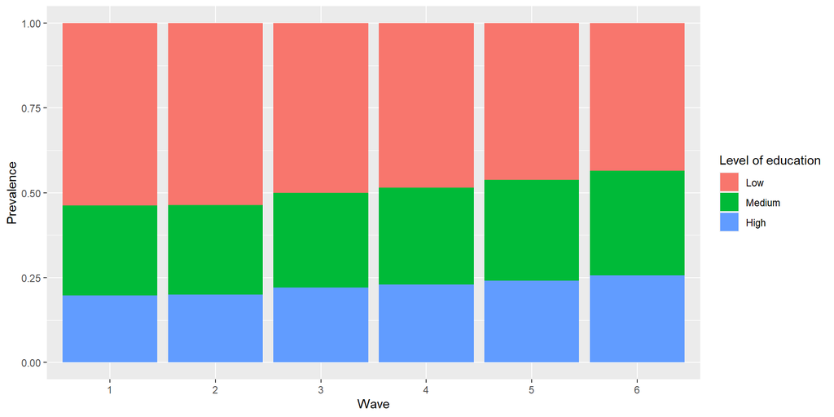

```r
ggplot() +
  geom_col(
    mapping = aes(
      x = factor(wave),
      y = prevalence,
      fill = education
    ),
    data = doetinchem.prevalence.by.wave.and.education
  ) +
  labs(
    x = "Wave",
    y = "Prevalence"
  ) +
  scale_fill_discrete(
    name = "Level of education",
    labels = c("L" = "Low", "M" = "Medium", "H" = "High")
  )
```

## Age

Let’s check, per wave, what the minimum, mean and maximum age is.

```r
doetinchem.data %>%
  group_by(wave) %>%
  summarise(
    min.age = min(age),
    mean.age = mean(age),
    max.age = max(age),
    .groups = "drop"
  )
```

| wave | min.age | mean.age | max.age |
| --- | --- | --- | --- |
| 1 | 20.12320 | 40.35417 | 59.81109 |
| 2 | 26.08077 | 46.45357 | 65.84805 |
| 3 | 31.02259 | 51.02637 | 70.86927 |
| 4 | 36.14511 | 55.56597 | 75.91513 |
| 5 | 40.86790 | 59.89972 | 80.70637 |
| 6 | 45.85626 | 63.98880 | 85.80972 |

We can visualise the age distribution in a boxplot.

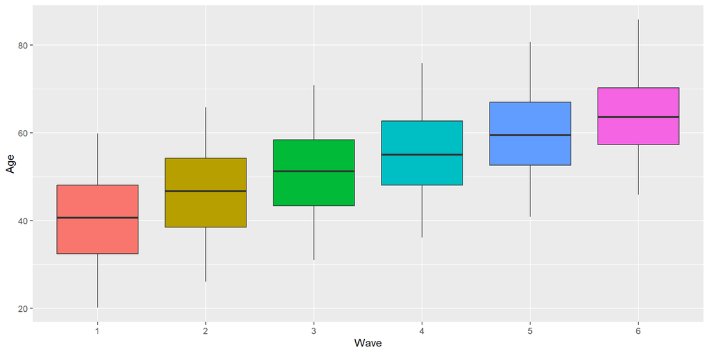

```r
ggplot() +
  geom_boxplot(
    mapping = aes(
      x = factor(wave),
      y = age,
      fill = factor(wave)
    ),
    data = doetinchem.data,
    show.legend = FALSE
  ) +
  labs(
    x = "Wave",
    y = "Age"
  )
```

We can also visualise the probability density of the age distribution by wave.

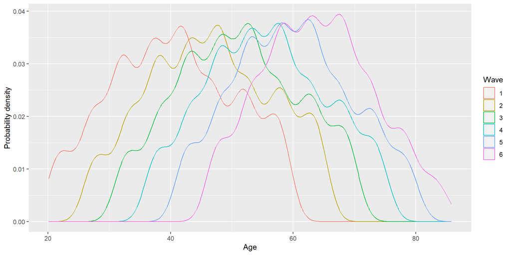

```r
ggplot() +
  geom_density(
    mapping = aes(
      x = age,
      col = factor(wave)
    ),
    data = doetinchem.data
  ) +
  labs(
    x = "Age",
    y = "Probability density",
    col = "Wave"
  )
```

## BMI

Let’s check, per wave, what the minimum, mean and maximum BMI value is.

```r
doetinchem.data %>%
  group_by(wave) %>%
  summarise(
    min.bmi = min(bmi),
    mean.bmi = mean(bmi),
    max.bmi = max(bmi),
    .groups = "drop"
  )
```

| wave | min.bmi | mean.bmi | max.bmi |
| --- | --- | --- | --- |
| 1 | 14.71125 | 24.61334 | 47.36122 |
| 2 | 15.85414 | 25.54042 | 48.40618 |
| 3 | 15.01750 | 26.15041 | 52.40221 |
| 4 | 15.26557 | 26.55652 | 55.13265 |
| 5 | 15.69883 | 26.84123 | 55.99595 |
| 6 | 16.04876 | 26.83455 | 49.82423 |

We can visualise the BMI distribution in a boxplot.

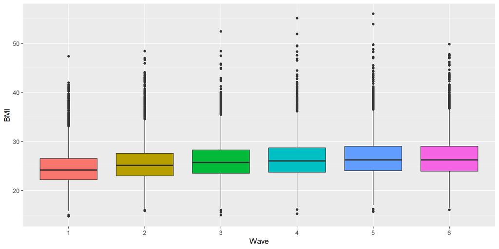

```r
ggplot() +
  geom_boxplot(
    mapping = aes(
      x = factor(wave),
      y = bmi,
      fill = factor(wave)
    ),
    data = doetinchem.data,
    show.legend = FALSE
  ) +
  labs(
    x = "Wave",
    y = "BMI"
  )
```

We can also visualise the probability density of the BMI distribution by wave.

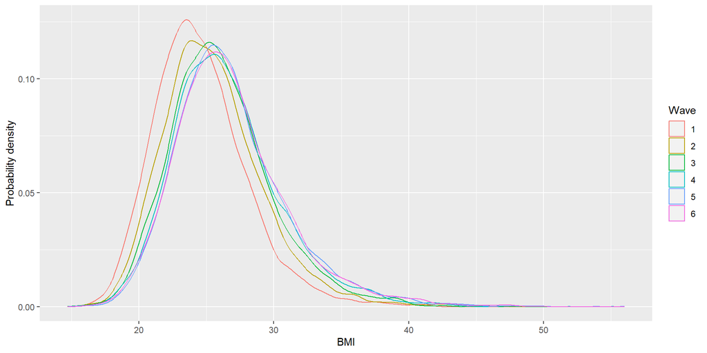

```r
ggplot() +
  geom_density(
    mapping = aes(
      x = bmi,
      colour = factor(wave)
    ),
    data = doetinchem.data
  ) +
  labs(
    x = "BMI",
    y = "Probability density",
    col = "Wave"
  )
```

Additionally, we can sample a few participants and visualise their BMI trajectory over the 6 waves. Note that we add a small amount of random noise to these trajectories. This is because the Doetinchem data are not open access. To request access to the data, please visit www.rivm.nl/doetinchem-cohort-studie.

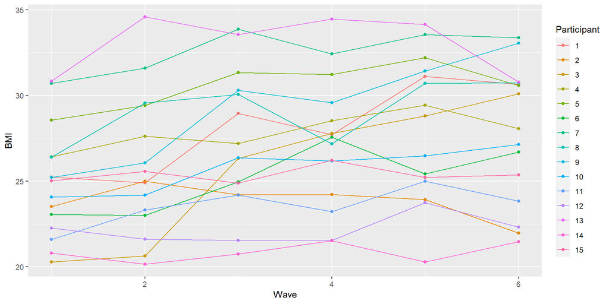

```r
ggplot(
  mapping = aes(
    x = wave,
    y = bmi,
    col = factor(participant.id)
  ),
  data = doetinchem.data %>%
    group_by(participant.id) %>%
    filter(n() == 6) %>%
    nest() %>%
    ungroup() %>%
    slice_sample(n = 15) %>%
    mutate(participant.id = seq(n())) %>%
    unnest(data) %>%
    mutate(bmi = bmi + rnorm(n(), 0, 0.5))
) +
  geom_line() +
  geom_point() +
  labs(
    x = "Wave",
    y = "BMI",
    col = "Participant"
  )
```

# Write Output

Finally, we write the cleaned data for the Doetinchem Cohort Study to a CSV file.

```r
write_csv(
  x = doetinchem.data,
  file = "../Output-Data/Doetinchem.csv"
)
```

# References

Huntington-Klein, Nick. 2021. *Vtable: Variable Table for Variable Documentation*. https://CRAN.R-project.org/package=vtable.

Pedersen, Thomas Lin. 2022. *ggforce: Accelerating ’ggplot2’*. https://CRAN.R-project.org/package=ggforce.

Picavet, H. S. J., Anneke Blokstra, Annemieke M. W. Spijkerman, and W. M. Monique Verschuren. 2017. “Cohort Profile Update: The Doetinchem Cohort Study 1987–2017: Lifestyle, Health and Chronic Diseases in a Life Course and Ageing Perspective.” *Int. J. Epidemiol.* 46 (6): 1751–1751g. https://doi.org/10.1093/ije/dyx103.

Verschuren, W. M. M., A. Blokstra, H. S. J. Picavet, and H. A. Smit. 2008. “Cohort Profile: The Doetinchem Cohort Study.” *Int. J. Epidemiol.* 37 (6): 1236–41. https://doi.org/10.1093/ije/dym292.

Wickham, Hadley, Mara Averick, Jennifer Bryan, Winston Chang, Lucy D’Agostino McGowan, Romain François, Garrett Grolemund, et al. 2019. “Welcome to the tidyverse.” *Journal of Open Source Software* 4 (43): 1686. https://doi.org/10.21105/joss.01686.

Wickham, Hadley, and Evan Miller. 2021. *Haven: Import and Export ’SPSS’, ’Stata’ and ’SAS’ Files*. https://CRAN.R-project.org/package=haven.